# DATA 607: Week 10 Assignment

## Sentiment Analysis With Inner Join

### Most Frequent Positive Words

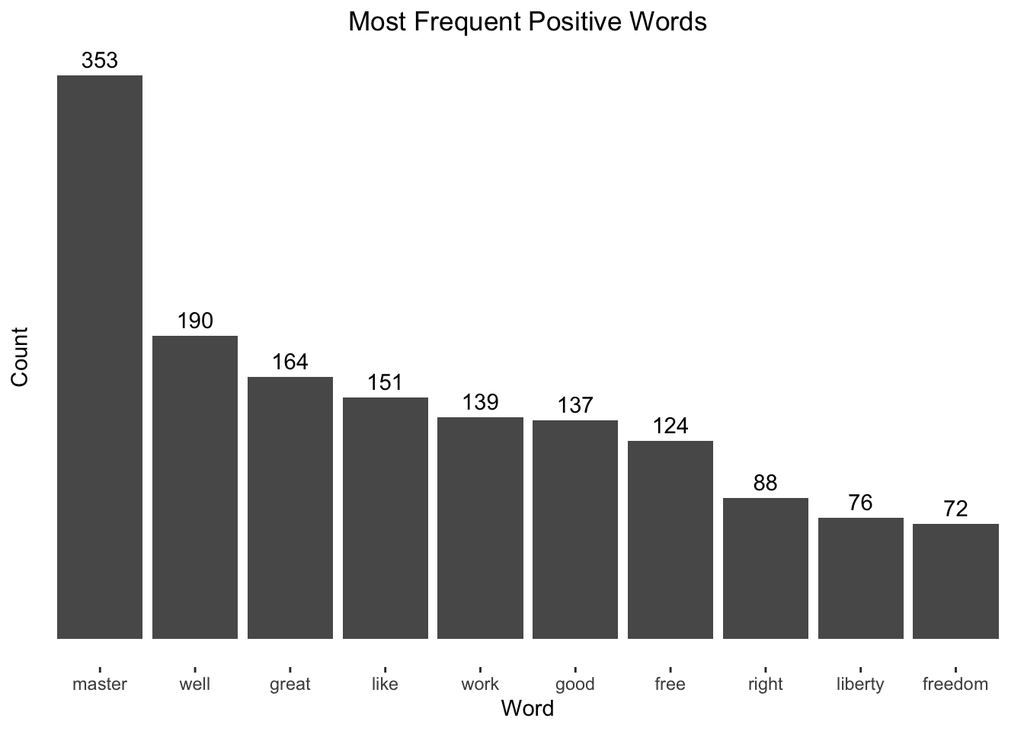

```r
bondage %>%
  inner_join(get_sentiments("bing")) %>%
  filter(sentiment == "positive") %>%
  count(word, sentiment, sort = TRUE) %>%
  top_n(10) %>%
  mutate(word = reorder(word, desc(n))) %>%
  ggplot() +
  aes(x = word, y = n) +
  labs(title = "Most Frequent Positive Words") +
  ylab("Count") +
  xlab("Word") +
  geom_col() +
  geom_text(aes(label = n, vjust = -.5)) +
  theme(
    panel.background = element_rect(fill = "white", color = NA),
    axis.text.y = element_blank(),
    axis.ticks.y = element_blank(),
    plot.title = element_text(hjust = 0.5)
  )
```

### Most Frequent Negative Words

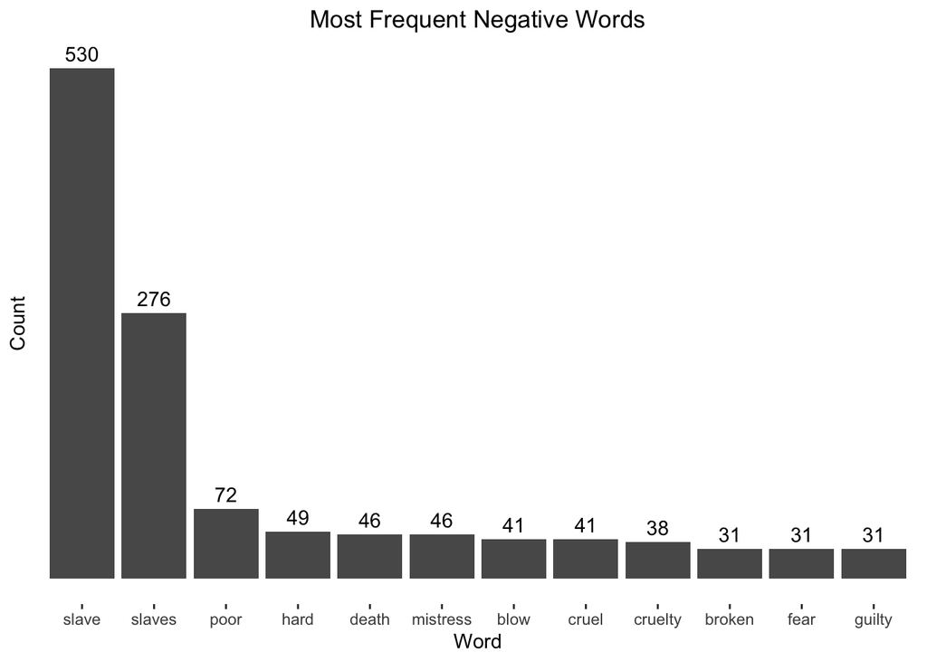

```r
bondage %>%
  inner_join(get_sentiments("bing")) %>%
  filter(sentiment == "negative") %>%
  count(word, sentiment, sort = TRUE) %>%
  top_n(10) %>%
  mutate(word = reorder(word, desc(n))) %>%
  ggplot() +
  aes(x = word, y = n) +
  labs(title = "Most Frequent Negative Words") +
  ylab("Count") +
  xlab("Word") +
  geom_col() +
  geom_text(aes(label = n, vjust = -.5)) +
  theme(
    panel.background = element_rect(fill = "white", color = NA),
    axis.text.y = element_blank(),
    axis.ticks.y = element_blank(),
    plot.title = element_text(hjust = 0.5)
  )
```

### Wordclouds

Let’s look at the most common words in Frederick Douglasss’s book with wordcloud.

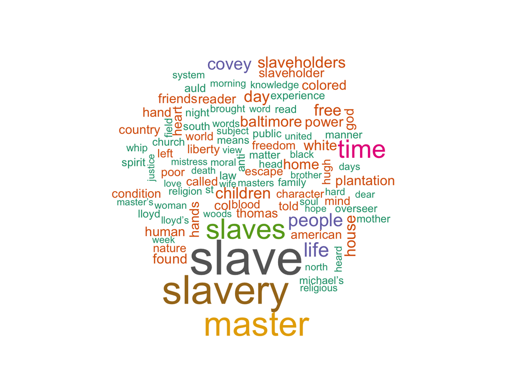

```r
library(RColorBrewer)
# Color palette for the wordclouds
colors <- brewer.pal(8, "Dark2")
# Wordcloud of non-stopwords
bondage %>%
  anti_join(stop_words) %>%
  count(word) %>%
  with(wordcloud(word, n, max.words = 100, color = colors))
```

Above the most common words in Frederick Douglasss’s autobiographical slave narrativ.

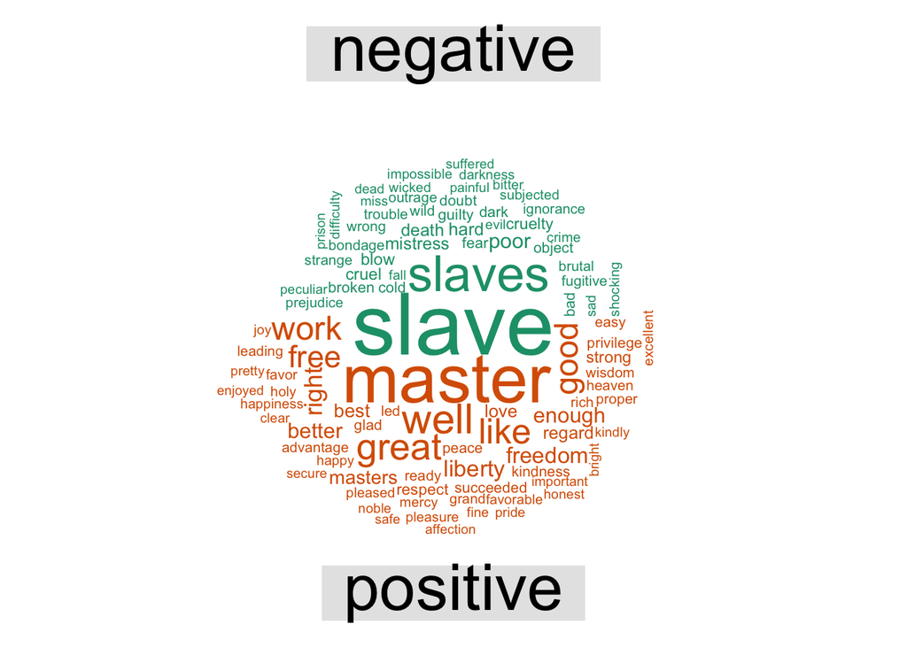

```r
# Sentiment analysis to tag positive and negative words using an inner join, then find the most common positive and negative words
bondage %>%
  inner_join(get_sentiments("bing")) %>%
  count(word, sentiment, sort = TRUE) %>%
  acast(word ~ sentiment, value.var = "n", fill = 0) %>%
  comparison.cloud(colors = colors,
                   max.words = 100)
```

The size of a word’s text above is in proportion to its frequency within its sentiment. We can use this visualization to see the most important positive and negative words, but the sizes of the words are not comparable across sentiments.

# Loughran Sentiment Lexicon

We will use [loughran](https://rdrr.io/cran/tidytext/man/get_sentiments.html) lexicon that we have researched.

**Note**: If you initially encounter problems loading loughran, you will need to accept the license for the lexicon by typing in the console for R Markdown

```r
lghrn <- get_sentiments("loughran")
unique(lghrn$sentiment)
```

```
## [1] "negative"     "positive"     "uncertainty"  "litigious"    "constraining"
## [6] "superfluous"
```

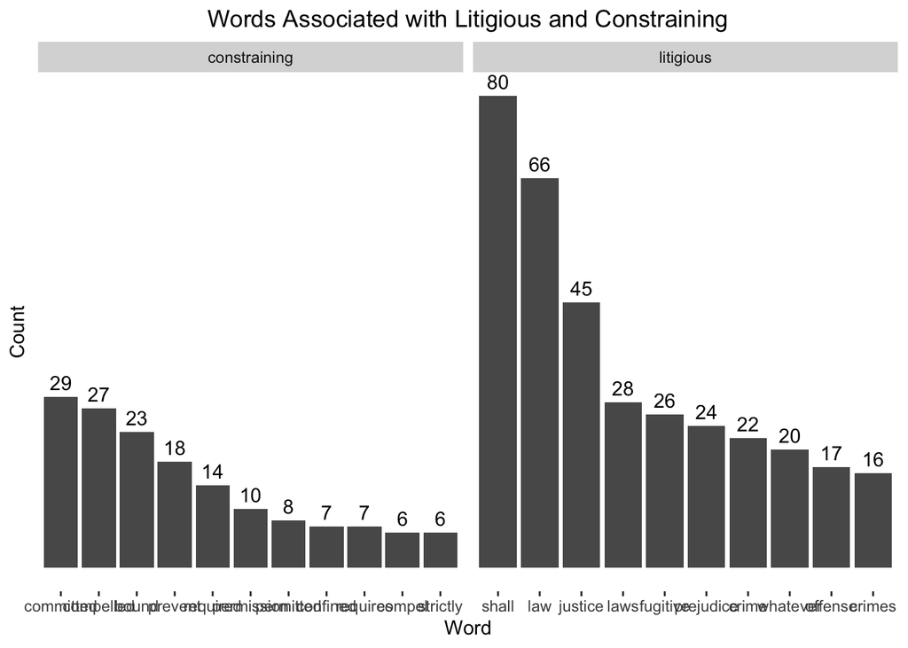

```r
#let’s explore the lexicon to see what types of words are litigious and constraining.
bondage_index %>%
  unnest_tokens(word, text) %>%
  inner_join(get_sentiments("loughran")) %>%
  filter(sentiment %in% c("litigious", "constraining")) %>%
  count(word, sentiment, sort = TRUE) %>%
  group_by(sentiment) %>%
  top_n(10) %>%
  ggplot() +
  aes(x = reorder(word,desc(n)), y = n) +
  geom_col() +
  facet_grid(~sentiment, scales = "free_x")  +
  geom_text(aes(label = n, vjust = -.5)) +
  labs(title = "Words Associated with Litigious and Constraining") +
  ylab("Count") +
  xlab("Word") +
  theme(
    panel.background = element_rect(fill = "white", color = NA),
    axis.text.y = element_blank(),
    axis.ticks.y = element_blank(),
    plot.title = element_text(hjust = 0.5)
  )
```

# Conclusion

This assignment has allowed us to explore the topic of sentiment analysis. We have successfully implemented and expanded upon the main example code from chapter 2 of the Text Mining with R book. We have used three different sentiment lexicons: ‘AFINN’, ‘bing’, and ‘nrc’ to analyze the sentiment of Jane Austen’s novels. Further, by using the ‘gutenbergr’ library we have explored the “My Bondage and My Freedom” by Frederick Douglass. We have tidied the dataset with one-token-per-row by using the unnest_tokens () function. We have used our sentiment analysis with inner join to be able to find the most frequent positive words and most frequent negative words. From our findings, we can see the respective most frequent positive and negative words are **master** and **slave**. These two words are also look like the most common words using wordcloud. Moreover, we filter the ‘loughran’ sentiment lexicon to include only words with a “litigious” and “constraining” sentiment. The resulting data frame is then filtered to include only words from “bondage” and is counted using count () to show the frequency of words with a “litigious” and “constraining” sentiments.From here, we can see that the words associated with litigious results are more than constraining.